# StatGenet2017

ryamada

Tuesday, November 15, 2016

# 1 Basics

### 1.0.1 Skills of answering questions ~ Brief description and definition

Check “what definition is” and “how to write definition” if you are not familiar with definition.

What definitin is : https://en.wikipedia.org/wiki/Definition

How to write definition : https://en.wikipedia.org/wiki/Wikipedia:Writing_better_articles/Define_and_describe

「定義とは」「定義の仕方」を確認すること。

定義とは：https://ja.wikipedia.org/wiki/定義

定義の仕方：https://ja.wikipedia.org/wiki/Wikipedia:定義と記述

## 1.1 Terms of statistical genetics and basics of R and statistics

### 1.1.1 EdX Mooc

Take the section 1 of the EdX Mocc course “Introduction to Statistical Methods of Gene Mapping.”

https://www.edx.org/course/introduction-statistical-methods-gene-kyotoux-005x

### 1.1.2 Check your knowledge on genetics and genetic heterogenetity

医学科卒業時に必要な知識を以下に示す。講義開始にあたり、自身の知識を確認し、各項目につき短文で説明できるようにせよ。

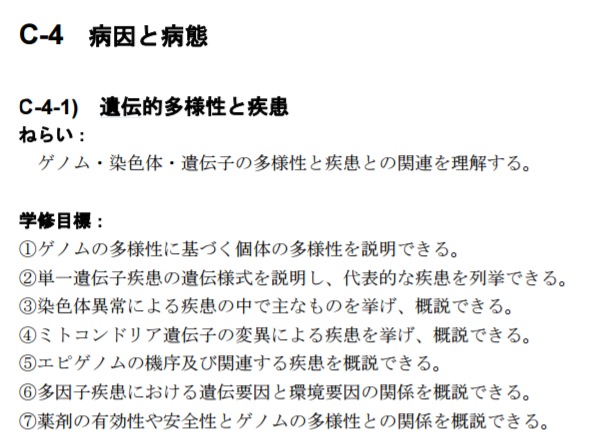

C-4 Disease pathology and clinical features

C-4-1 Genetic diversity and diseases

aim) Understand the relationship between diversity in genome, chromosome, and genes and diseases

Study goals are to;

1: be able to describe individual diversity based on genetic diversity

2: be able to describe genetic modes of monogenic disorders and to make a list of representative monogenic disorders

3: be able to cite an example of chromosomal abnormalities and to outline it

4: be able to cite an example of diseases due to mutations of mitochondial genes and to outline it

5: be able to outline epigenomic mechanism of epigenome and its relating disorder

6: be able to outline relation between genetic factors and environmental factors in multifactorial disorders

E Systemic physiological changes, clinical features, diagnosis, and treatments

E-1-1 Genetic medical service, genome medicine and the characteristics of their information

aim) understand the characteristics of genetic and genome information and study diagnosis and treatment of the patients and supports of preclinical individuals and their family based on genetic and genome information.

## 1.2 No background on molecular genetics?

現在やっている講義内容よりもウェット寄りの基礎事項を確認したい人は、学部１回生向けの分子遺伝学テキストのドラフトをアップしました(こちら)ので使ってください

Sorry for Japanese only. If you think more wetty contents are useful for your progress in statistical genetics, a draft version of text of “molecular genetics” for 1st grade undergraduate might be helpful. The draft is @ http://statgenet-kyotouniv.wikidot.com/bunsiidengaku2017 .

# 2 Mendelian traits

## 2.1 Pedigree

Are you new to “R”? -> Go through “Basics of R”. In Japanese http://www.slideshare.net/m884/japan-r-15432969 In English http://www.cyclismo.org/tutorial/R/

Draw a trio of parents and a male offspring. Mother and the child are affected.

ID

1 : father

2 : mother

3 : male offspring

sex

1 : male

2 : female

affected

0 : non-affected

1 : affected

```r
#install.packages("kinship2")
library(kinship2)
```

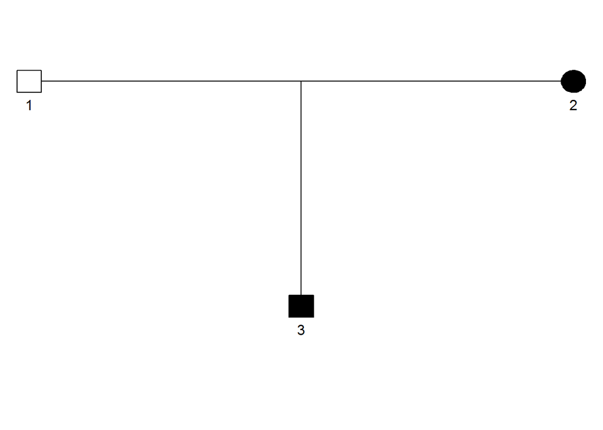

```
[Exercise]
Make vectors of id, mom, dad, sex for a family with 10 or more members and 3 or more generations.
Draw a pedigree manually on a sheet of paper, then make vectors.

ex.
id <- 1:11
mom <- c(0,0,2,2,0,0,5,5,6,6,6)
dad <- c(0,0,1,1,0,0,4,4,7,7,7)
sex <- c(1,2,1,1,2,2,1,2,2,1,2)
affected <- sample(0:1,11,replace=TRUE)
print(affected)
ptemp<-pedigree(id=id,dadid=dad,momid=mom,sex=sex,affected=affected)

plot(ptemp)
```

```r
id  <- c(1, 2, 3)
mom <- c(0, 0, 2)
dad <- c(0, 0, 1)
sex <- c(1, 2, 1)
affected <- c(0,1,1)

ptemp<-pedigree(id=id,dadid=dad,momid=mom,sex=sex,affected=affected)
plot(ptemp)
```

## 2.2 Genotypes and phenotypes of mendelian traits

### 2.2.1 Genotypes

“00”, “01”, and “11”.

0 : “00”

0.5 : “01”

1 : “11”

Assign genotypes to the pedigree memebers. You can assign genotypes to the members without paretns. You can assign genotypes to the members with parents with restriction.

```r
gen <- c(1,0,0.5)
```

### 2.2.2 Phenotypes (non-affected/affected)

“0” and “1”.

### 2.2.3 Genetic models

Dominant model means

$$phenotype \ = 0 \ when \ genotype \ = 0 \\
phenotype \ = 1 \ when \ genotype \ = \ 0.5 \ or \ 1$$

```r
my.dom <- function(g){
  ph <- rep(0,length(g))
  for(i in 1:length(g)){
    if(g[i]>0){
      ph[i] <- 1
    }
  }
  return(ph)
}
my.dom(gen)
```

```
## [1] 1 0 1
```

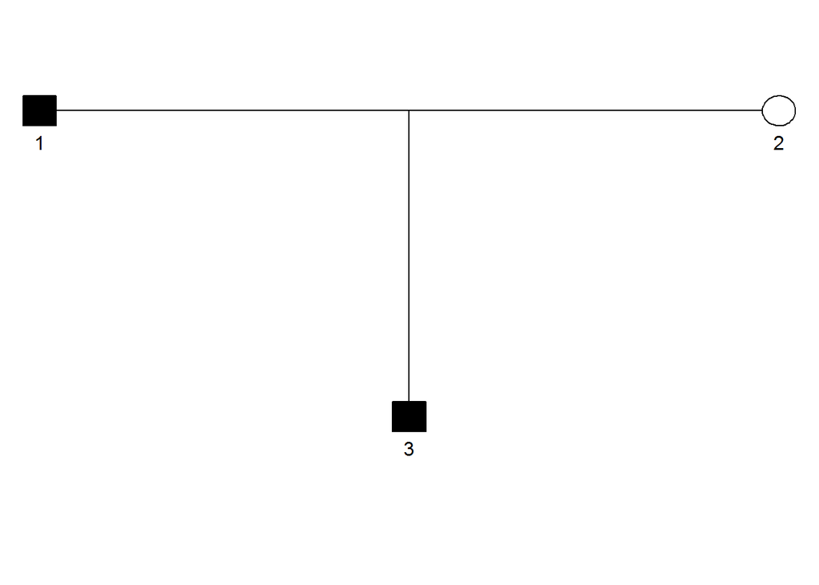

```
[Exercise]
Make a function, my.rec(), that returns phenotype in recessive model.
```

```
[Exercise]
Assigne genotypes (0,0.5,1) to the members of your pedigree with 10 or more members and 3 or more generations. Then calculate their phenotype in dominant and recessive models and draw pedigrees, respectively.

eg.
id <- 1:11
mom <- c(0,0,2,2,0,0,5,5,6,6,6)
dad <- c(0,0,1,1,0,0,4,4,7,7,7)
sex <- c(1,2,1,1,2,2,1,2,2,1,2)
gen <- c(0,1,0.5,0.5,1,0,1,0.5,0.5,0.5,0.5)
ph.dom <- my.dom(gen)
affected <- ph.dom
ptemp<-pedigree(id=id,dadid=dad,momid=mom,sex=sex,affected=affected)
plot(ptemp)

ph.rec <- my.rec(gen)
affected <- ph.rec
ptemp<-pedigree(id=id,dadid=dad,momid=mom,sex=sex,affected=affected)
plot(ptemp)
```

```r
affected <- my.dom(gen)
ptemp<-pedigree(id=id,dadid=dad,momid=mom,sex=sex,affected=affected)
plot(ptemp)
```

### 2.2.4 Penetrance and phenocopy

Penetrance is the probability that phenotype “1” appears for people with corresponding genotype(s).

Probability to develop phenotype “1” is 0, penetrance, and penetrance for three genotypes 0, 0.5 and 1, respectively, when dominant.

```r
my.dom2 <- function(g,penet){
  ph <- rep(0,length(g))
  prob <- c(0,penet,penet)
  for(i in 1:length(g)){
    if(runif(1)<= prob[g[i]]){
      ph[i] <- 1
    }
  }
  return(ph)
}
```

```
[Exercise]
Answer probability to develope phenotype "1" for recessive model with penetrance.

Make a function, my.rec2(), for the case.
```

[output not shown]

Phenocopy is the probablity that phenotype “1” appears for people without corresponding genotype(s).

Probability to develop phenotype “1”is, phenocopy, 1, and 1 for three genetypes 0, 0.5 and 1, respectively, when dominant.

```
[Exercise]
Make a function, my.dom3(), that returns phenotype for dominant model with phenocopy.

Make a function, my.rec3(), that returns phenotype for recessive model with phenocopy.
```

Phenotype developing probability vector for dominant model is

(pheno, penet, penet). The vector for recessive model is (pheno, pheno, penet).

```
[Exercise]

Make a function, my.dom4(), for dominant model reflecting phenocopy and penetrance.

Make a function, my.rec4(), for recessive model.
```

### 2.2.5 Genotype-specific probability to develop phenotype “1”

Dominant and recessive models with penetrance and phenocopy specify phenotype developing probability vector.

(pheno, penet, penet)

(pheno, pheno, penet),

respectively.

We can make a function that takes the probability vecrot and returns phenotype.

```r
my.pheno <- function(g,prob){
  ph <- rep(0,length(g))
  #prob <- c(pheno,pheno,penet)
  for(i in 1:length(g)){
    if(runif(1)<= prob[g[i]]){
      ph[i] <- 1
    }
  }
  return(ph)
}
```

[output not shown]

[output not shown]

## 2.3 NGS and Disease-responsible mutations

### 2.3.1 Readings

#### 2.3.1.1 NGS and genes related to diseases

Read the retivew below and grab the idea what UGS does for genetic disease studies A review “Identifying Highly Penetrant Disease Causal Mutations Using Next Generation Sequencing: Guide to Whole Process”.

https://www.hindawi.com/journals/bmri/2015/923491/

#### 2.3.1.2 Basics to interpret functional significance of identified variants

https://www.ncbi.nlm.nih.gov/pubmed/16824020

“Predicting the effects of amino acid substitutions on protein function.” by Ng PC and Henikoff S.

http://www.acgs.uk.com/media/774853/evaluation_and_reporting_of_sequence_variants_bpgs_june_2013_-_finalpdf.pdf

“Practice Guidelines for the Evaluation of Pathogenicity and the Reporting of Sequence Variants in Clinical Molecular Genetics” by Yvonne Wallis et al.

```
[Exercise]
-以下の諸点を考慮し、どのようなバリアントがありえるかを出来る限り細かく分類列挙し、その重要性の順序を答えよ(複数のバリアントがあったときに、ただ１つのバリアントを選ぶことのみが許されると仮定して順序をつけよ)。Consider all the points below, classify single-nucleotide variant-type variants into as many types as possible. Assume you have to select only 1 variant among multiple variants regardless of uncertainty.

-たんぱく質コーディング遺伝子構造上にある一塩基置換型の遺伝子バリアントを考える。Consider single-nucleotide substitution-type genetic variants in a protein-coding gene.
構造上の位置、エクソン(5'UTR,3'UTR,non-UTR),イントロン(Known to be functional for splicing,others), 5'-upstream (known to be important for expression regulation, others), 3'-downstream (known to be important for expression regulation, others)を考慮せよ。Consider location of the variant in the gene structure (exon (5'UTR,3'UTR,non-UTR),intron(Known to be functional for splicing,others), 5'-upstream (known to be important for expression regulation, others), 3'-downstream (known to be important for expression regulation, others))

-non-UTR-exonについてはそのペプチド鎖構造への影響の仕方も考慮せよ。 and also include information of effects on the peptide chain in the case of non-UTR exonic variants.アミノ酸置換型バリアントについては、アミノ酸置換のタイプについて考慮するとともに、分子高次構造における機能性評価についても言及せよ。For the variants with amino-acid substitution, consider the type of amino-acid substitution beside the location in the molecular higher-order structure.

-発現調節領域の遺伝子バリアントの影響予測法についても言及せよ。Consider prediction methods of genetic variants on expression-regulatory regions.
ここに示された条件以外は無条件とせよ。Assume no information besides mentioned above is available and you should consider the conditions not mentioned should be equal among the variants to be compared.

##
Hints

The section "Distinguishing between benign & deleterious mutations" would be helpful to learn how to classify the ways to quantitate functionality of variants.

https://www.ncbi.nlm.nih.gov/pmc/articles/PMC4437232/

"Distinguishing between benign & deleterious mutations"というセクションが、バリアントの機能性定量方法の分類を学ぶための訳に立つでしょう。

(Table4 で用いられている"Functional prediction programs." のカテゴリ　‡Category keys = 1: Protein stability; 2: Protein sequence and structure; 3: Sequence and evolution conservation; 4: Machine learning; 5: Data for benchmark; 6: Database; 7: Consensus classifier; 8: Conservation and frequency.）
```

### 2.3.2 Data handling for variant calls of NGS

If you have no background on next generation sequencing technology, read a review on it.

Sequencing

Mapping

Variant calling

Filtering

Ranking

### 2.3.3 Variant calling ~ Coverage depth and variant detection

#### 2.3.3.1 二項分布 Binomial distribution

[output not shown]

When reading a heterozygous locus with depth x50, the number of reads of one allele distributes in binomial distribution.

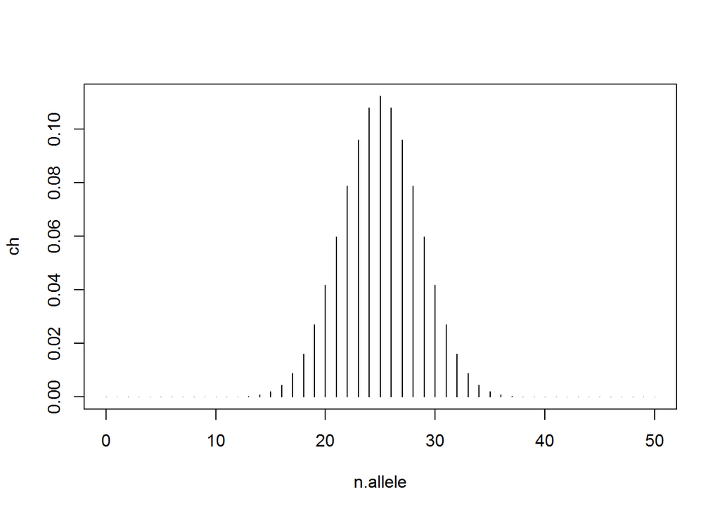

```r
depth <- 50
n.allele <- 0:depth
ch <- dbinom(n.allele,depth,prob=c(0.5,0.5))
plot(n.allele,ch,type="h")
```

NGS produce errors. Therefore some reads at a homozygous locus may look heterozygous-like.

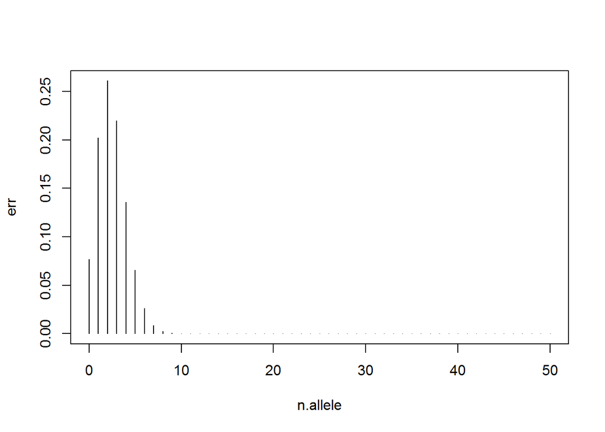

```r
error.p <- 0.05

err <- dbinom(n.allele,depth,prob=error.p)
plot(n.allele,err,type="h")
```

Overlap the plots.

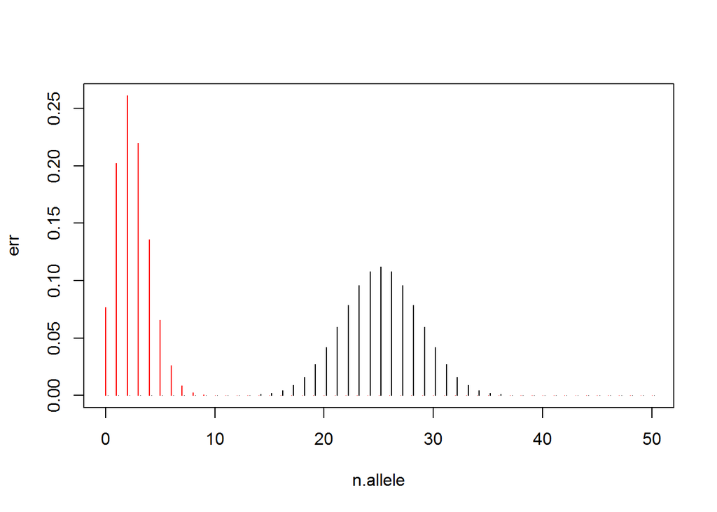

```r
plot(n.allele,err,type="h",col=2)
points(n.allele+0.2,ch,type="h")
```

### 2.3.4 Distinguish heterozygous signals and error signals

```
[Exercise]
-以下をシミュレーションせよ Simulate below.

-N loci Ｎローカス

-Their depth follow Poisson distribution with mean m (for example 30) デプスは平均m(たとえば30)のポアソン分布に従う

-アレルは{0,1}とする。Assume alleles as {0,1}

-Hetero/Homo follows in Binomial distribution with frac of hetero being h (for example 0.2) ヘテロ/ホモの別はヘテロ率h (たとえば0.2)の二項分布に従う

-アレルが0のときに、実験コールが0の確率をp、実験コールが1の確率を1-pとする When their true allele is 0, experimental call is 0 with prob p and call is 1 with prob 1-p.

-アレルが1のときに、実験コールが1の確率をq、実験コールが0の確率を1-qとする When their true allele is 1, experimental call is 1 with prob q and call is 0 with prob 1-q.

-ヘテロとコールするか、ホモとコールするか、未決とコールするかの基準と、その正答パフォーマンスについて検討せよ Place a rule to call heterozygous/homozygous/undetermined and evaluate the relation between the rule and variant call performance.
```

#### 2.3.4.1 Likelihood and likelihood ratio

If your result is 25 vs. 25, likelihoods of both assumptions are:

```r
k <- 25
ch[which(n.allele==k)]
```

```
## [1] 0.1122752
```

```r
err[which(n.allele==k)]
```

```
## [1] 1.045018e-19
```

Likelihood ratio is:

```r
ch[which(n.allele==k)]/err[which(n.allele==k)]
```

```
## [1] 1.074385e+18
```

Log-likelihood ratio is :

```r
log10(ch[which(n.allele==k)]/err[which(n.allele==k)])
```

```
## [1] 18.03116
```

```
[Exercise]
Calculate likelihood ratio and log-likelihood ratio for observations 0 to 50 and plot them.
```

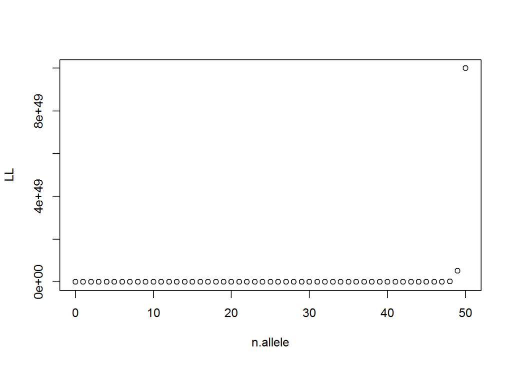

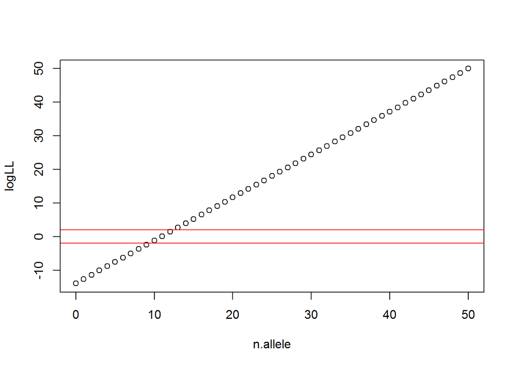

When n.allele is less than a cut-off value 1, the locus might be called “homozygous” and more than a cut-off value 2, “heterozygous”, otherwise uncertain.

```
[Exercise]
We learned how to estimate the number of reads that is required to cover the genome with an average depth. Can you estimate the number so that at least p (for example 0.95) of genome should be covered with depth x or more? You may use poisson hypothesis or negative binomial.
```

#### 2.3.4.2 Prior 1 ~ Majority loci are homozygous

If we have a good reason to believe that the locus can be heterogygous and homozygous evenly, then the prior probability of both assumptions are 0.5, respectively.

Throughout the genome, heterozygous sites in an individual are one out of several hundreds or so… then, the prior should be (0.003, 0.997).

```r
prior <- c(0.003,0.997)
post.ch <- ch[which(n.allele==k)] * prior[1]
post.err <- err[which(n.allele==k)] * prior[2]
post.ch/post.err
```

```
## [1] 3.232854e+15
```

```r
log10(post.ch/post.err)
```

```
## [1] 15.50959
```

```
[Exercise]
Drow likelihood ratio and log-likelihood ratio based on the prior and draw them.
```

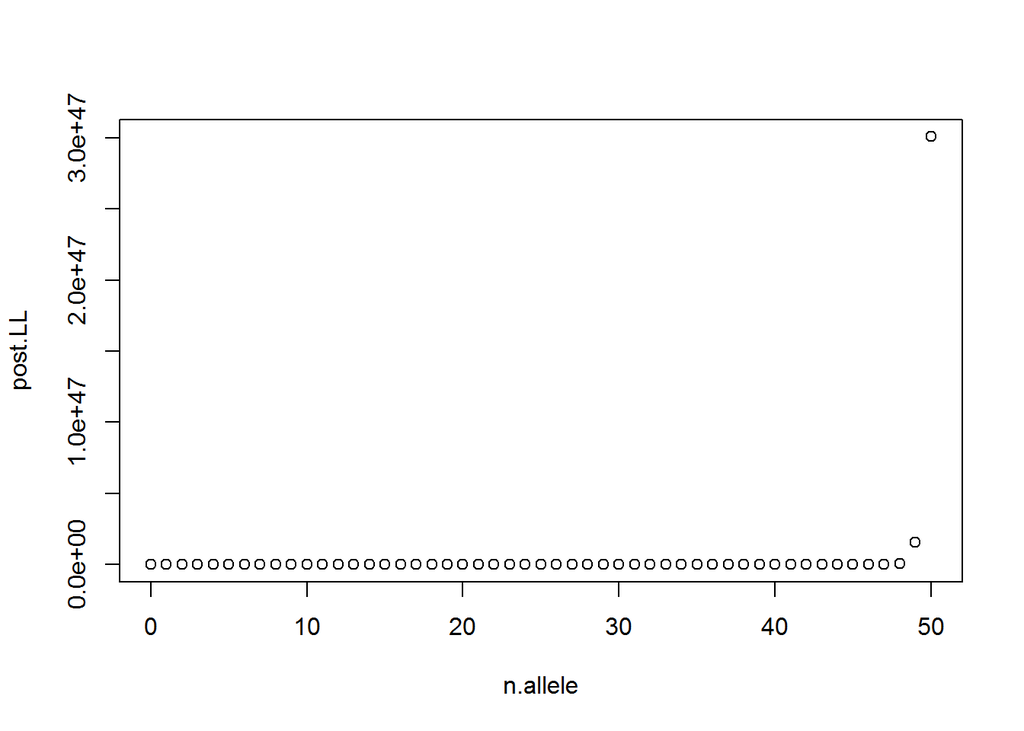

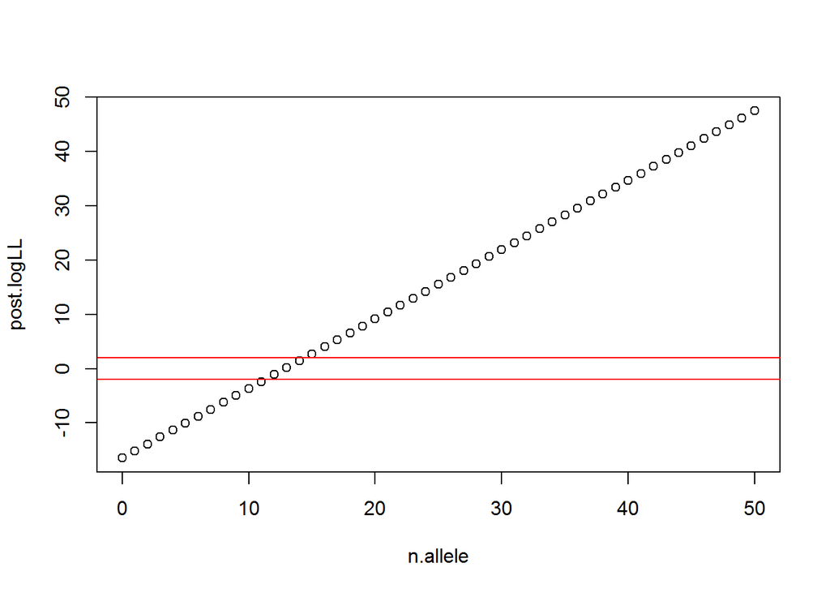

When n.allele is less than a cut-off value 1, the locus might be called “homozygous” and more than a cut-off value 2, “heterozygous”, otherwise uncertain.

```
[Exercise]
Do the same for different depth values, including x5, x10, x20, x30, x40.
Check the cut-off values and plot the cut-off values along the depth values.
```

#### 2.3.4.3 Prior 2 ~ Bayesian estimation of heterozygous frequency of known variant loci

If this site is known to be a single nucleotide variant locus, then what is the prior?

##### 2.3.4.3.1 Allele frequency and HWE

When allele frequency of the SNP is given and HWE is assumed:

$$1 = (p+(1-p))^2 = p^2 + \ 2\times p (1-p) + \ (1-p)^2$$

```r
allele.freq <- 0.3
another.freq <- 1-allele.freq
another.freq
```

```
## [1] 0.7
```

```r
my.diplofreq.hwe <- function(allele.freq){
  another.freq <- 1-allele.freq
  ret <- c(allele.freq^2,2*allele.freq*another.freq,another.freq^2)
  return(ret)
}
my.diplofreq.hwe(allele.freq)
```

```
## [1] 0.09 0.42 0.49
```

```
[Exercise]
Calculate heterozygous frequency in HWE for allele frequency ranging from 0 to 1 and plot the results.
```

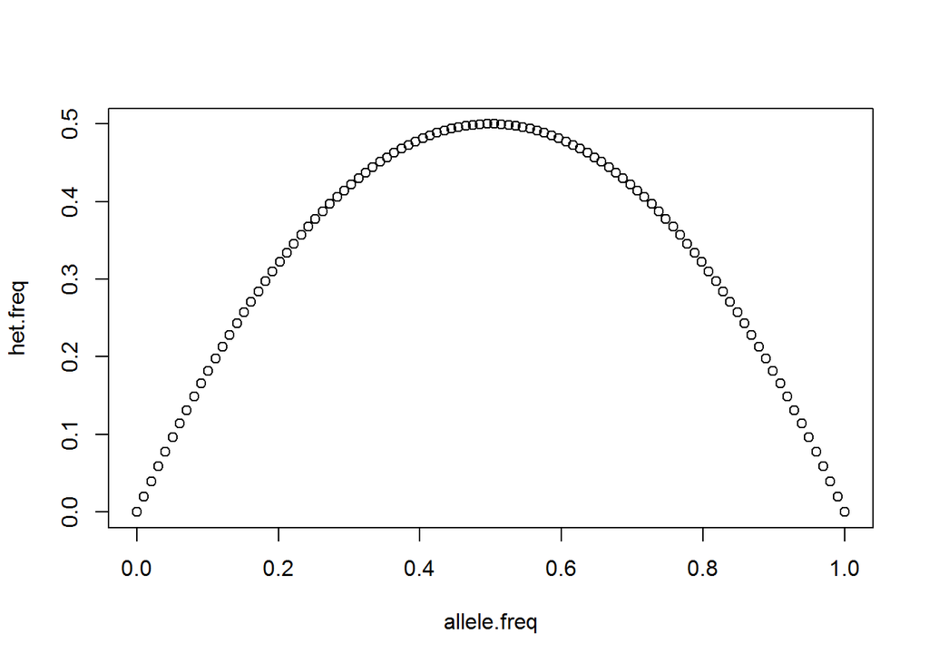

Prior shouldbe $ 1-2p(1-p) vs. 2p(1-p) $.

##### 2.3.4.3.2 Diplotype frequency and HWD

When number of individuals per diplotype is given as $g_{00},g_{01},g_{11}$,$G=g_{00}+g_{01}+g_{11}$,

allele frequency is $f = \frac{g_{00} + g_{01}/2}{G}$.

Observed diplotype frequency : $g_{00},g_{01},g_{11}$ .

Expected diplotype frequency under the assumption of HWE : $G f^2,2Gf(1-f),G(1-f)^2$.

The deviation of the observed counts from the expected values can be measured with $\chi^2$ statistics.

```r
g <- c(10,20,15)
G <- sum(g)
f <- (g[1]+g[2]/2)/G
f
```

```
## [1] 0.4444444
```

```r
g.hwe <- my.diplofreq.hwe(f) * G
chi2 <- sum((g-g.hwe)^2/g.hwe)
chi2
```

```
## [1] 0.45
```

```r
my.hwe.test <- function(g){
  G <- sum(g)
  f <- (g[1]+g[2]/2)/G
  g.hwe <- my.diplofreq.hwe(f)*G
  chi2 <- sum((g-g.hwe)^2/g.hwe)
  return(chi2)
}
```

##### 2.3.4.3.3 Random sampling from null hypothesis, HWE

Assume a population whose allele frequency is f and who is in HWE. We can sample N individuals from the population at random and observe the genotype counts and calculate $chi^2$ value to test HWE.

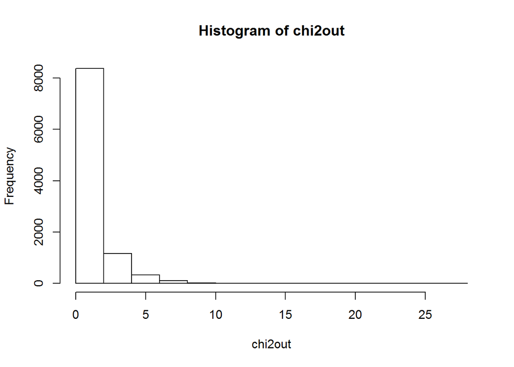

```r
f <- 0.3
g.hwe <- my.diplofreq.hwe(f)
N <- 100
n.iter <- 10^4
chi2out <- rep(0,n.iter)
for(i in 1:n.iter){
  smpl <- sample(0:2,N,replace=TRUE,prob=g.hwe)
  tmp.g <- tabulate(smpl+1,nbins=3)
  chi2out[i] <- my.hwe.test(tmp.g)
}
hist(chi2out)
```

$chi^2$ distribution: https://en.wikipedia.org/wiki/Chi-squared_distribution

The plot of df = 1 is most similar.

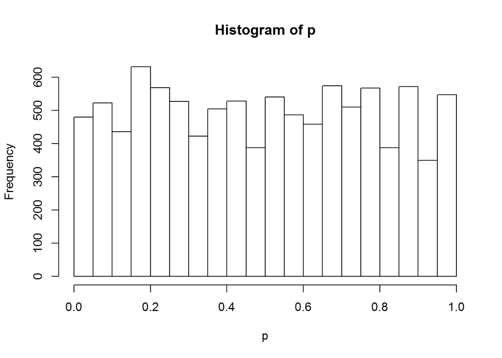

```r
p <- pchisq(chi2out,df=1,lower.tail=FALSE)
hist(p)
```

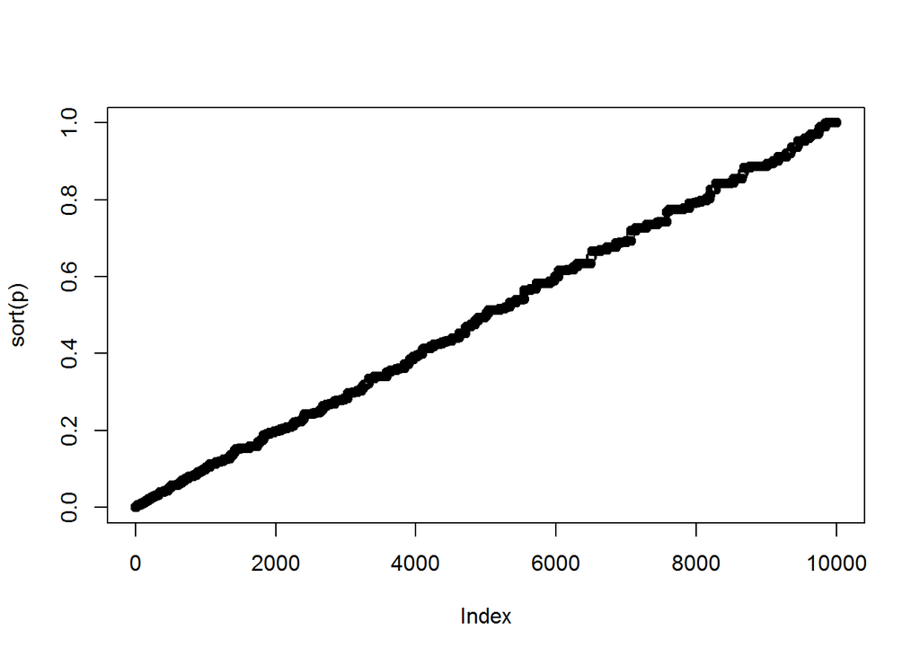

```r
plot(sort(p))
```

Degree of freedom is 1.

```
[Exercise]
Check yourself,
```

$$g_{obs,00} = g_{hwe,00} + \delta \\
g_{obs,01} = g_{hwe,01} - 2 \delta \\
g_{obs,11} = g_{hwe,11} + \delta+ /delta$$

```
are true.
```

```
[Exercise]
-Simulation of HWD

-Assume a population that is consisted of two sub-populations with fraction, 0.5 and 0.5.

-Assume many SNPs.

-Give minor allele frequency for one sub-population with minor allele frequency distributes in uniform distribution (0,0.5].

-Give minor allele frequency for the other sub-population in the same way but independently from the 1st sub-pop.

-Assume a fraction r of both sub-population choose a partner from the opposite sub-population and the rest choose a partner from the same sub-population.

-Let all make pairs and have two offsprings. The offsprings are the new-generation population.

-Calculate three genotype  frequency of all SNPs of the newer generation.

-You can test the SNPs for HWE with my.hwe.test() function in the text. Obtain distribution of chi-sq and p and discuss relation between these statistical value distributions and r.
```

##### 2.3.4.3.4 Bayesian estimation of heterozygous frequency

When observed n samples and m out of n were heterozygous:

Probability to observe (m, n-m) when frequency of heterozygous is f is:
$$\begin{pmatrix} n \\ m \end{pmatrix} f^m (1-f)^{n-m}$$

This is also likelihood of f with observation of (m, n-m).

When observation is binomial, beta distribution is its likelihood function.

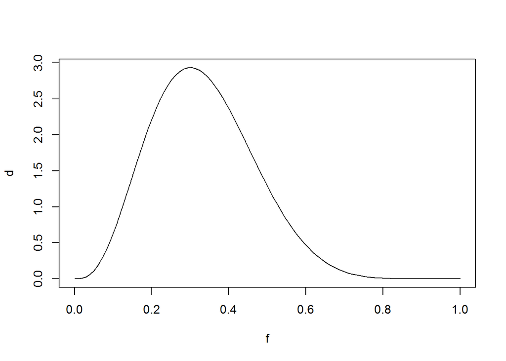

```r
n <- 10
m <- 3
f <- seq(from=0,to=1,length=100)
d <- dbeta(f,m+1,(n-m)+1)
plot(f,d,type="l")
```

We may use this distribution of f as the prior.

# 3 Cancer-syndromes

## 3.1 Basics

Cancers are common diseases and therea are subsets among them that are strongly hereditary, which are called cancer syndromes.

BRCA1 and BRCA2 are such examples causing breast/ovarian cancers frequently.

BRCA1, BRCA2など、特定の癌の発病リスクを高める遺伝子変異が知られている。

遺伝要因が特に高いサブポピュレーションである。

The recommendations for cancer-syndromes are:

このようなサブポピュレーションへの対応は、

１ Score risk possessing the responsible variants without prior genetic testings. 遺伝要因を保有しているリスクが高いと考えられる場合に

２ Do genetic counseling 遺伝的カウンセリングを行ったうえで

３ Then do genetic testing 遺伝子検査を実施し

４ If positive, decside what to do. 結果に応じて予防対策を決定する

というやり方が推奨されている。https://www.uspreventiveservicestaskforce.org/Page/Document/RecommendationStatementFinal/brca-related-cancer-risk-assessment-genetic-counseling-and-genetic-testing

For the step 1, two methods, a simple scoring system and a Bayesian risk estimation, BRCA-Pro are handled and for the step 4, a web-based decision tool, BRCA tool is handled.

１を行うツール例として、Scoring system (項目別得点形式)とBRCA-Pro http://bcb.dfci.harvard.edu/bayesmendel/brcapro.php を、

４を行うツール例として、BRCA decision tool http://brcatool.stanford.edu/brca.html

について理解する

## 3.2 Decision tools

### 3.2.1 BRCA decision tool

#### 3.2.1.1 Use the tool

BRCA decision tool http://brcatool.stanford.edu/brca.html

```
[Exercise]
Using Stanford BRCA tool, evaluate relation between outcome probabilities and its option parameters (age, BRCA1/2 status, Screening methods and prophylactic procedures). Stanford BRCA toolを使って、年齢、BRCA1/2、スクリーニング法、予防的処置と、その帰結との関係がどうなっているかを調べ、説明しなさい・
```

## 3.3 Risk assessment

### 3.3.1 Ontario Family History Assessment Tool

http://www.wikidoc.org/index.php/BRCA_screening_tools

How do you read the table?

How do you describe the scores?

```
[Exercise]
Why "Breast and ovarian" and "Breast" are separate?

Why "Breast and ovaria" has higher scores than "Breast (only)"?

How do you describe the difference in score values of "Breast (only)" and "Ovarian (only)"?

How do you describe the score values of "Mother", "Sibling" and "Second-/third-degree relative" ?

Why is "Male relative (Breast)" specifically handled?

Describe the score values of "age/life stage" information.
```

```
[Exercise]
Read https://en.wikipedia.org/wiki/Clinical_prediction_rule or something similar and write a description note on how to make decision criteria to your friends.

https://en.wikipedia.org/wiki/Clinical_prediction_rule　、もしくは類する何かを呼んで、決断クライテリアの作り方に関する友人向けの説明文を書け
```

#### 3.3.1.1 Likelihood ratio gets bigger with multiple events

Two hypotheses: $p1$ to cause a cancer vs. $p2$ to cause a cancer; $p1 < p2$.

The hypothesis with $p1$ is “no responsible variat” but “phenocopy”.

The hypothesis with $p2$ is “yes responsible variant” with “penetrance < 1”.

When one cancer is observed, likelihood of two hypotheses are $p1$ and $p2$.

When two cancers are observed, likelihood are $p1^2$ and $p2^2$.

Likelihood ratio gets bigger:

$$\frac{p2^2}{p1^2} = \frac{p2}{p1} \times \frac{p2}{p1} > \frac{p2}{p1}$$

#### 3.3.1.2 Breat vs. Ovary; Female vs. Male

$p1$ represents probability to develop it without the variant, in other words, the baseline probability … prevalence.

Prevalence of breast vs. ovary ?

Prevalence of breast cancer in female vs. male?

Prevalences of two cancer types; $p1.1 < p1.2$.

If rare events happen at random, it follows Poisson distribution.

Assume you get cold m times per year in average from age 0 to 100.

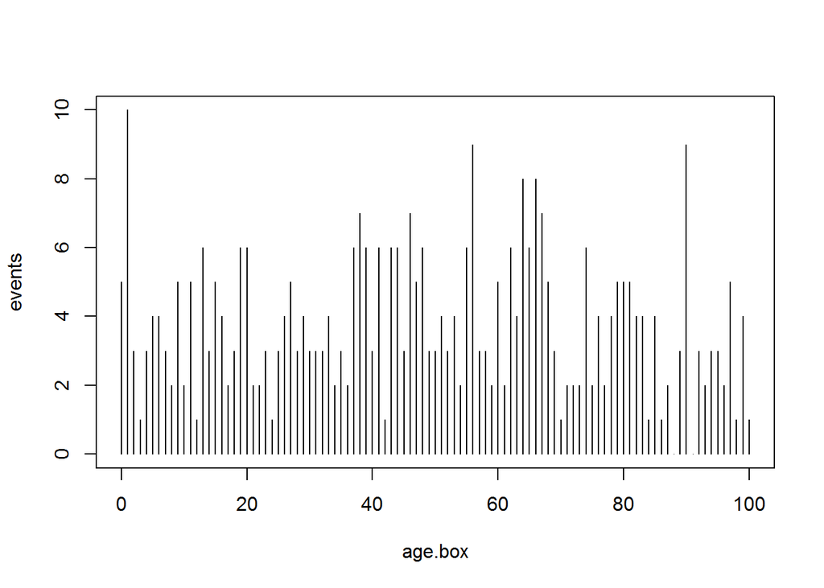

```r
age.box <- 0:100
m <- 4
events <- rpois(length(age.box),m)
plot(age.box, events,type="h")
```

```r
table(events)
```

```
## events
##  0  1  2  3  4  5  6  7  8  9 10
##  2  9 18 24 15 12 13  3  2  2  1
```

Much infrequent event, eg. cancer…

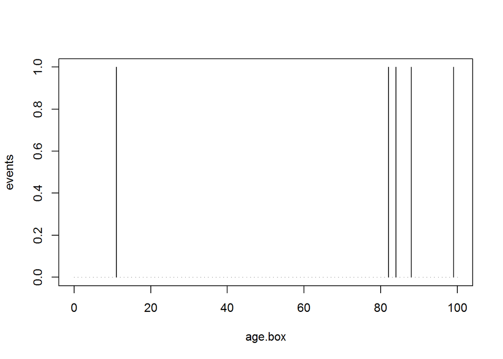

```r
m <- 0.1
events <- rpois(length(age.box),m)
plot(age.box, events,type="h")
```

```r
table(events)
```

```
## events
##  0  1
## 96  5
```

The first cancer episode should be focused because cancer is more significant than common colds.

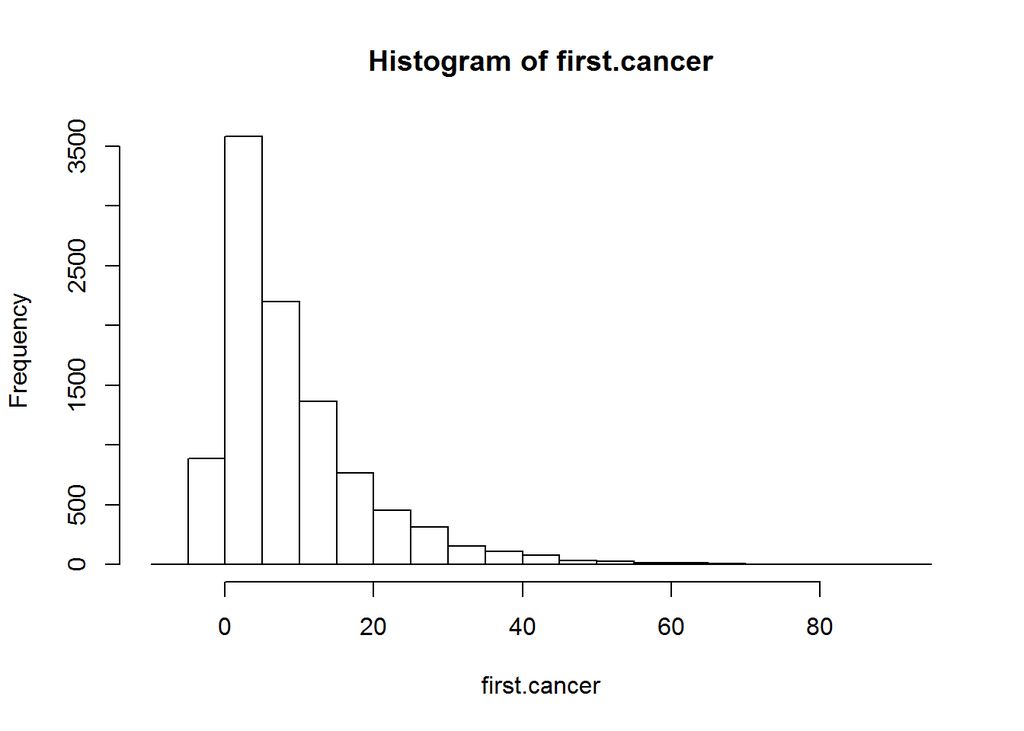

```r
n.ind <- 10^4
first.cancer <- rep(-9,n.ind)
for(i in 1:n.ind){
  events <- rpois(length(age.box),m)
  tmp <- which(events > 0)
  if(length(tmp)>0){
    first.cancer[i] <- tmp[1] - 1
  }
}
hist(first.cancer)
```

This is in exponential distribution.

This distribution does not fit to one of age of onset of adult cancers.

Assumption of multi-hit-accumulation:

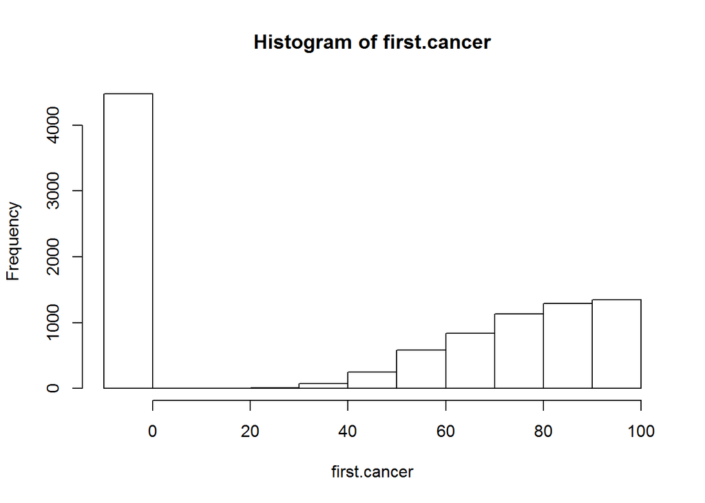

```r
n.hit <- 10
first.cancer <- rep(-9,n.ind)
for(i in 1:n.ind){
  events <- rpois(length(age.box),m)
  cumsum.events <- cumsum(events)
  tmp <- which(cumsum.events >= n.hit)
  if(length(tmp)>0){
    first.cancer[i] <- tmp[1] - 1
  }
}
hist(first.cancer,breaks=seq(from=-10,to=100,by=10))
```

Many people are free from cancer and age of onset of first cancer distributes in a good shape.

The possession of responsible variant increases the average value m.

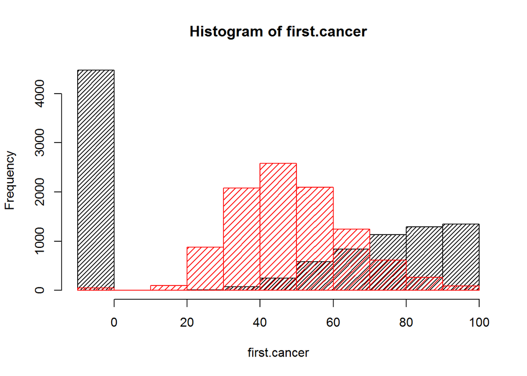

```r
n.hit <- 10
m2 <- 0.2
first.cancer2 <- rep(-9,n.ind)
for(i in 1:n.ind){
  events <- rpois(length(age.box),m2)
  cumsum.events <- cumsum(events)
  tmp <- which(cumsum.events >= n.hit)
  if(length(tmp)>0){
    first.cancer2[i] <- tmp[1] - 1
  }
}
h1 <- hist(first.cancer,breaks=seq(from=-10,to=100,by=10),density=25)
h2 <- hist(first.cancer2,breaks=seq(from=-10,to=100,by=10), add=TRUE,col=2,density=17)
```

```r
h1$counts
```

```
##  [1] 4473    0    0   11   75  247  584  837 1134 1291 1348
```

```r
h2$counts
```

```
##  [1]   50    1   96  876 2079 2582 2099 1242  616  266   93
```

```
[Exercise]
How many people did survive till age 100 without cancer with m=0.1 and m=0.2, respectively?

Answer likelihood ratio m=0.2 over m=0.1 for the survivors?

How about for the patients who developed cancer in their 40s?

Calculate likelihoods for other xxties and plot them.
Pay attention to the age the more likely model changes from one to the other.
```

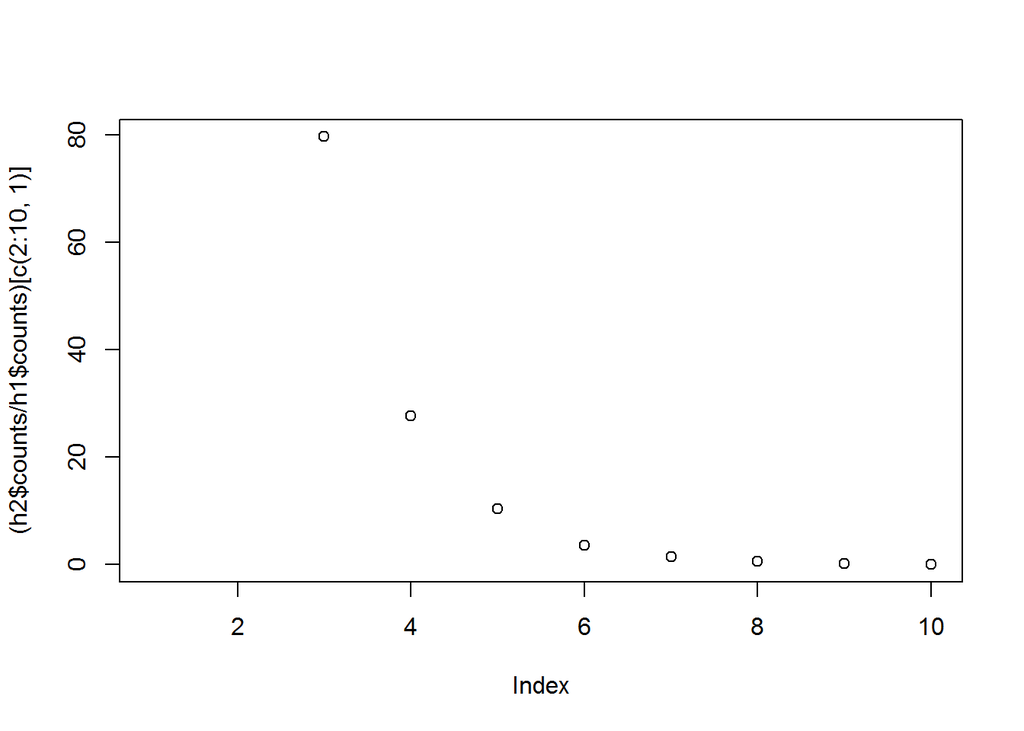

#### 3.3.1.3 kinship relationship

1. Phenotype of mother -> likeliness of mother having the variant
2. likeliness of mother having the variant -> likeliness of self having the variant.

Blood relationship affects (2).

```
[Excersize]
Make a pedigree that contains, (mother,daughter), (sisters), (aunt,niece),(female-cousins) and draw a pedigree.
Using kinship() function, calculate kinship between the pairs.

eg.
library(kinship2)
example(kinship)
plot(tped)
```

#### 3.3.1.4 Calculation of scores

Each factor has a point.

$$score = \sum_{i=1}^{n.factors} p_i \times x_i \ ; \ x_i \in \{0,1\}$$

```
[Excercise]
Generate a function to calculate Ontario Family Hisory Assessment Tool score.
```

```
## [1] 14
```

Score measures or estimates how likely an individual posesses the variant.

The formula above is in the shape of linear regression.

#### 3.3.1.5 What is a scoring system?

##### 3.3.1.5.1 Quantitative measure

Monotonic relation between a measure and risk.

x : measurable item

y : risk

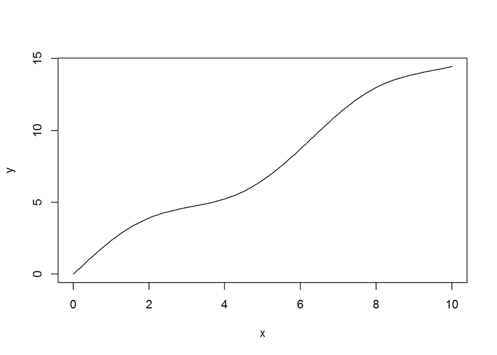

```r
x <- seq(from=0,to=10,length=100)
y <- sin(x) + 1.5*x
plot(x,y,type="l")
```

Measuring x and returning y as a score.

Risk itself is not known but we know that x and risk are in monotonic relation.

Then, higher x should have higher score.

Value of x might be used as score itself but…

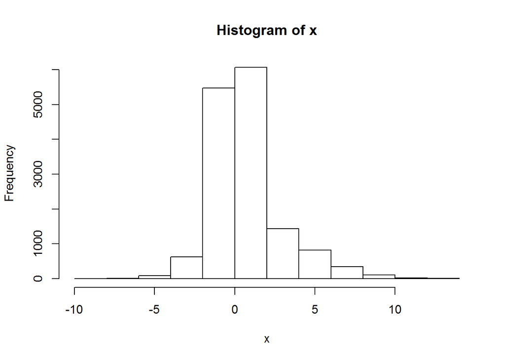

```r
x <- c(rnorm(10000),rnorm(5000,2,3))
hist(x)
```

```r
length(which(x<=5))/length(x)
```

```
## [1] 0.9434667
```

Standardization:

The minimum x gets a score 1/N.

The median x gets a score 0.5.

The maximum x gets a score 1.

##### 3.3.1.5.2 Two dimensional measures.

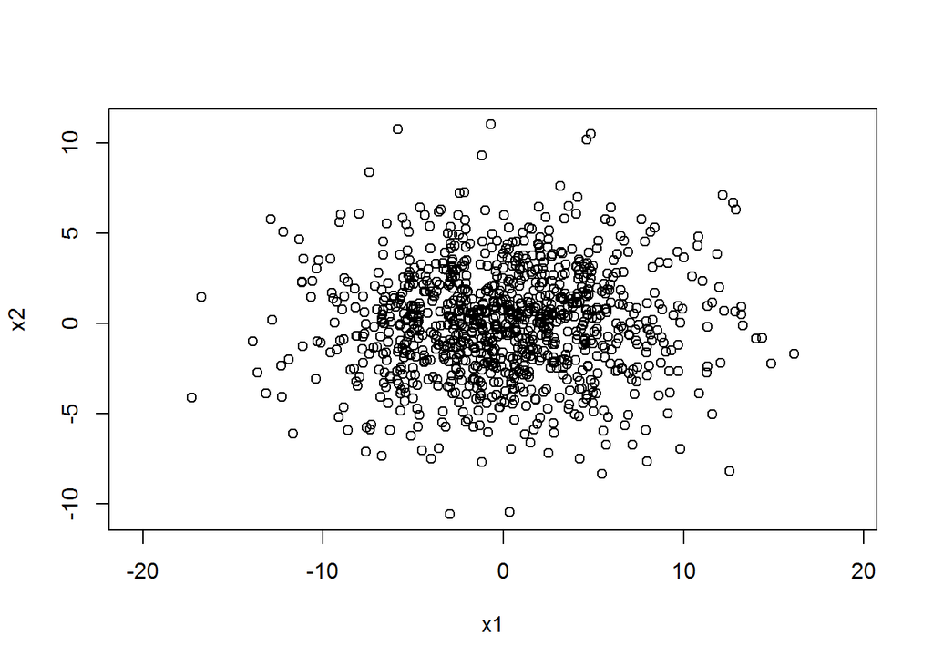

```r
x1 <- rnorm(1000) * 5
x2 <- rnorm(1000) * 3
plot(x1,x2,asp=1)
```

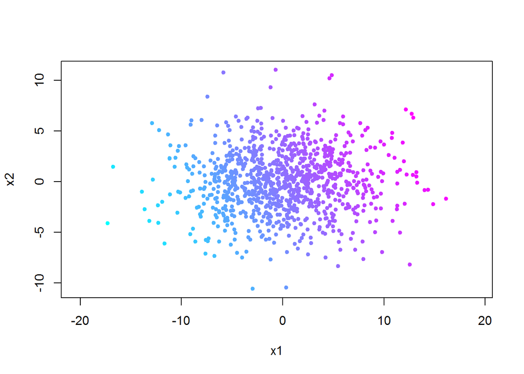

```r
a1 <- 2.3
a2 <- 1.2
b <- 5
y <- a1 * x1 + a2 * x2 + b

y. <- (y-min(y))/(max(y)-min(y))

plot(x1,x2,pch=20,col=rgb(y.,1-y.,1),asp=1)
```

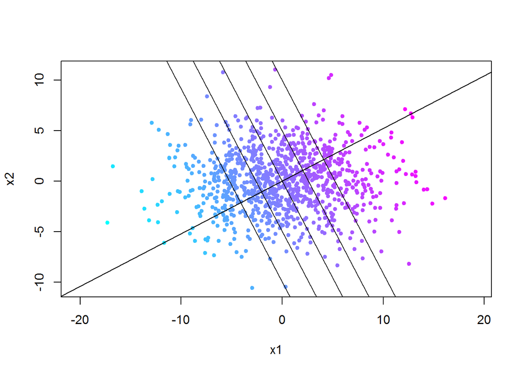

```r
plot(x1,x2,pch=20,col=rgb(y.,1-y.,1),asp=1)
abline(0,a2/a1)
abline(-10,-a1/a2)
abline(-5,-a1/a2)
abline(0,-a1/a2)
abline(5,-a1/a2)
abline(10,-a1/a2)
```

$$y ~ a1 \times x1 + a2 \times x2$$

Linear regression

```r
lm.out <- lm(y~x1 + x2)
lm.out
```

```
##
## Call:
## lm(formula = y ~ x1 + x2)
##
## Coefficients:
## (Intercept)           x1           x2
##         5.0          2.3          1.2
```

```r
lm.out$coefficients
```

```
## (Intercept)          x1          x2
##         5.0         2.3         1.2
```

```r
#predict(lm.out,2,3)
```

##### 3.3.1.5.3 Regression

Target variable.

Explanatory variables.

Making a formula to calculate target value with explanatory variables’ values.

How to design a scoring system?

Multiple items

A function to take multiple items and returns a scaler value.

##### 3.3.1.5.4 Linear regression vs. Non-linear regression

The likelihood ratios for age of onset bins:

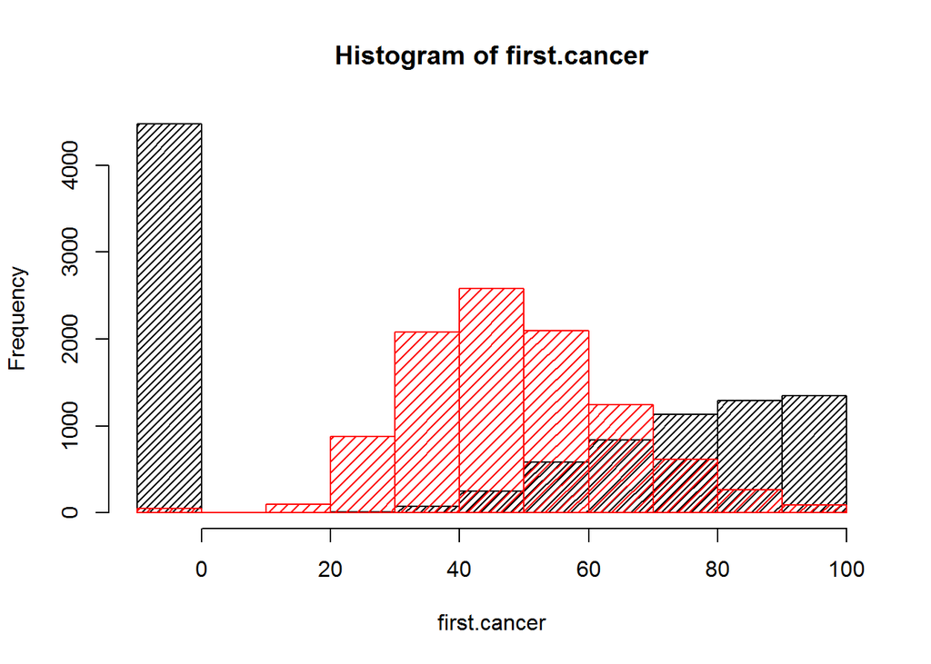

```r
h1 <- hist(first.cancer,breaks=seq(from=-10,to=100,by=10),density=25)
h2 <- hist(first.cancer2,breaks=seq(from=-10,to=100,by=10), add=TRUE,col=2,density=17)
```

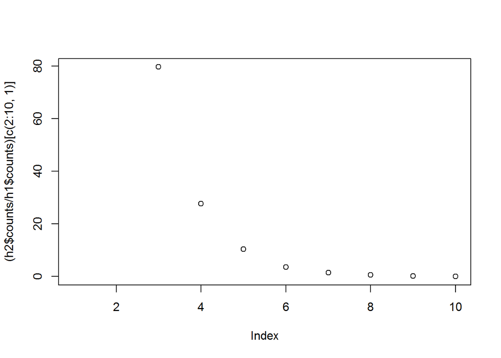

```r
plot((h2$counts/h1$counts)[c(2:10,1)])
```

Contribution of age (or age bins) is not simple.

Score of somebody whose mother and a sister developed breast cancer in early age should be higher than one whose mother developed in late but a sister in early.

Factor of relatives and factor of age of onset are mutually interrelated.

Those information would be more informative to estimate likeliness to possess the variant.

Bayesian network method can integrate all the information together.

### 3.3.2 BRCA-PRO ~ Bayesian network method

http://bcb.dfci.harvard.edu/bayesmendel/brcapro.php

Risk express : http://www.crahealth.com/risk-express

```
[Exercise]
-Risk expressを実行し、２種類の癌リスク遺伝子のバリアント保有率がともに高い架空データを入力し、その出力ファイルを提出するとともに、その出力ファイルの読み方の説明文を付けよ。

-Generate simulational individual and evaluate it with Risk express , so that it has high probability to have risk allele of both gene groups. Upload the output file and add description notes on it.
```

#### 3.3.2.1 What is Bayesian network?

Assume a pedigree in which a hereditary phenotype is running.

The appearance of the phenotype is age-dependent.

Bayesian network method can estimate individuals’ possession of responsible variant and genetic model with phenocopy and penetrance with age-depending function of disease development.

##### 3.3.2.1.1 Bayesian Network for BRCAPro

Sub text : “BayesianNetwork4BRCAPro.Rmd” @ http://www.statgenet.med.kyoto-u.ac.jp/StatGenet/lectures/2017/Statgenet2017/BayesianNetwork4BRCAPro.Rmd

or

http://www.statgenet.med.kyoto-u.ac.jp/StatGenet/lectures/2017/Statgenet2017/BayesianNetwork4BRCAPro.html

#### 3.3.2.2 Monte-carlo simulation to estimate outcomes

Paper: https://www.ncbi.nlm.nih.gov/pubmed/22231042

```
[Exercise]
Describe Table 1
```

Multiple factors for Monte-Carle simulation.

Stochastic effects of BRCA1/2 on the factors are based on previous studies.

```
[Exercise]
Describe how the BRCA decision tool simulate the life of individuals using the factors in the table.
```

### 3.3.3 参考(日本語のみ) Japanese only

「遺伝性乳癌卵巣癌症候群診療の手引き(ドラフト)」が厚労省等で作成中資料

http://www.statgenet.med.kyoto-u.ac.jp/StatGenet/lectures/2017/Statgenet2017/HereditaryCancerManualDraft2017.pdf

# 4 Exam

[output not shown]

[output not shown]

[output not shown]

[output not shown]

# 5 Complex genetic traits

## 5.1 Genetic models

### 5.1.1 Dominant,recessive,additve, multiplicative 遺伝モデル～優性・劣性・相加・相乗～

Assume a SNP whose minor allele (m) increases probability over the major allele (M) to develop a phenotype as:

MM : p0

Mm : p1 >= p0

mm : p2 >= p1

```
[Exercise]
Answer p0,p1 and p2 when genetic mode is dominant and penetrance is a and phenocopy is b.

Answer p0,p1 and p2 when genetic mode is recessive and penetrance is a and phenocopy is b.
```

Dominant model is $p1 = p2$.

Recessive model is $p0 = p1$.

Non-mendelian traits, $p0 < p1 < p2$.

```
[Exercise]
Describe molecular mechanisms that cause pure dominant or pure recessive traits.

Describe molecular mechanisms that cause non-pure dominant and non-pure recessive traits.
```

```
What kind of molecular mechanisms can produce additive model and multiplicative model, respectively?
```

## 5.2 Population, cohort 集団、コホート

In case of rare mendelian tratis, the frequency of responsible variant in population is very rare and the prevalence of the trait is also extremely rare.

Howevere common genetic traits are common (~ 1 % ~ half) in population and risk allele frequency is high.

Now we are to make a function to calculate fractions of genotypes per phenotypes of the whole population.

```r
prevalence <- 0.01
allele.f <- 0.3
# HWE as a whole
genotype.f <- c(allele.f^2,2*allele.f*(1-allele.f),(1-allele.f)^2)

genotypic.risk <- c(4,2,1)
relative.frac.case <- genotypic.risk * genotype.f
# the sum of frac.case should be prevalence
frac.case <- relative.frac.case * prevalence / sum(relative.frac.case)

frac.cont <- genotype.f - frac.case

frac.whole <- rbind(frac.case,frac.cont)

frac.whole
```

```
##                  [,1]        [,2]        [,3]
## frac.case 0.002130178 0.004970414 0.002899408
## frac.cont 0.087869822 0.415029586 0.487100592
```

```r
colSums(frac.whole)
```

```
## [1] 0.09 0.42 0.49
```

```r
rowSums(frac.whole)
```

```
## frac.case frac.cont
##      0.01      0.99
```

```r
my.snp.pop <- function(allele.f,prevalence,genotypic.risk){
  genotype.f <- c(allele.f^2,2*allele.f*(1-allele.f),(1-allele.f)^2)
  relative.frac.case <- genotypic.risk * genotype.f
  # the sum of frac.case should be prevalence
  frac.case <- relative.frac.case * prevalence / sum(relative.frac.case)
  frac.cont <- genotype.f - frac.case
  frac.whole <- rbind(frac.case,frac.cont)
  frac.whole
}
allele.f <- 0.2
prevalence <- 0.1
genotypic.risk <- c(3,2,1)
pop <- my.snp.pop(allele.f,prevalence,genotypic.risk)
pop
```

```
##                  [,1]       [,2]       [,3]
## frac.case 0.008571429 0.04571429 0.04571429
## frac.cont 0.031428571 0.27428571 0.59428571
```

```r
colSums(pop)
```

```
## [1] 0.04 0.32 0.64
```

```r
rowSums(pop)
```

```
## frac.case frac.cont
##       0.1       0.9
```

#### 5.2.0.1 Genotypic risk ratio and addtive model and multiplicative model

GRR : (9,3,1) means probabilities to develop a phenotype of homozygous and heterozygous genotypes are $\times 3 \times 3$ and $\times 3$ of baseline probability 1, respectively.

Calculation of risks is “multiplication”.

GRR : (3,2,1) means probalities to develop a phenotype of homozygous and heterozygous genotpypes are $+ 1 + 1$ and $+1$ from baseline 1, respectively.

Calcualtion of risks is “addition”.

```
[Exercise]
Answer genotypic risk ratio of dominant model with phenocopy = p and prevalence q.

Answer genotypic risk ratio of recessive model with phenocopy = p and prevalence q.
```

#### 5.2.0.2 Genotypic risk ratio and odds ratio

Pick a genotype as a baseline genotype and calculate odds ratios for the other two genotypes.

Odds ratio are close to the genotypic ratio whose base line riks = 1.

However the values are not exactly identical.

```r
allele.f <- 0.2
prevalence <- 0.01
genotypic.risk <- c(3,2,1)
pop <- my.snp.pop(allele.f,prevalence,genotypic.risk)
pop
```

```
##                   [,1]        [,2]        [,3]
## frac.case 0.0008571429 0.004571429 0.004571429
## frac.cont 0.0391428571 0.315428571 0.635428571
```

```r
(pop[1,1]*pop[2,3])/(pop[2,1]*pop[1,3])
```

```
## frac.case
##  3.043796
```

```r
(pop[1,2]*pop[2,3])/(pop[2,2]*pop[1,3])
```

```
## frac.case
##  2.014493
```

```
[Exercise]
Fix allele freq and parameterize prevalence.
Evaluate the relation between prevalence and discrepancy in genotypic risk ratios and genotypic risk ratios.
```

## 5.3 SNP 2x3 table and association tests

In the case-control sampling designs, we sample cases from case population and controls from control population.

```r
n.case <- 1000
n.control <- 1000

allele.f <- 0.2
prevalence <- 0.01
genotypic.risk <- c(2,1.5,1)
pop <- my.snp.pop(allele.f,prevalence,genotypic.risk)
pop.case <- pop[1,]
pop.control <- pop[2,]

sample.case <- rmultinom(1,n.case,prob=pop.case)
sample.control <- rmultinom(1,n.control,prob=pop.control)

tab <- rbind(c(sample.case),c(sample.control))
tab
```

```
##      [,1] [,2] [,3]
## [1,]   60  418  522
## [2,]   47  320  633
```

```
[Exercise]
Test sum of cases and controls for hwe.

Test cases and controls individually for hwe.

Generate a sample tables with low prevalence and high prevalence (0.5) and also test cases, controls and sum of cases and samples for hwe and discuss their deviation from hwe.
```

### 5.3.1 Table tests with df =2 or df=1

df=2 test will test any difference between cases and controls.

This test returns $chi^2$ value and it should be converted to p-value with df=2 $chi^2$ distribution.

```r
chisq.test(tab)
```

```
##
##  Pearson's Chi-squared test
##
## data:  tab
## X-squared = 25.261, df = 2, p-value = 3.272e-06
```

When you want to test dominant model, you can do as follow. This time you can use df=1 $chi^2$ distribution.

```r
test.weight <- c(1,1,0)
prop.trend.test(tab[1,],tab[1,]+tab[2,],test.weight)
```

```
##
##  Chi-squared Test for Trend in Proportions
##
## data:  tab[1, ] out of tab[1, ] + tab[2, ] ,
##  using scores: 1 1 0
## X-squared = 25.249, df = 1, p-value = 5.04e-07
```

For recessive model, the weight vector is $(1,0,0)$.

For additive model, $(1,0.5,0)$.

```r
test.weight <- c(1,0,0)
prop.trend.test(tab[1,],tab[1,]+tab[2,],test.weight)
```

```
##
##  Chi-squared Test for Trend in Proportions
##
## data:  tab[1, ] out of tab[1, ] + tab[2, ] ,
##  using scores: 1 0 0
## X-squared = 1.6687, df = 1, p-value = 0.1964
```

```r
test.weight <- c(1,0.5,0)
prop.trend.test(tab[1,],tab[1,]+tab[2,],test.weight)
```

```
##
##  Chi-squared Test for Trend in Proportions
##
## data:  tab[1, ] out of tab[1, ] + tab[2, ] ,
##  using scores: 1 0.5 0
## X-squared = 21.57, df = 1, p-value = 3.412e-06
```

#### 5.3.1.1 df=2 vs. df=1

Generate tables at random in null hypothesis and generate $chi^2$ value distribution for df=2 and df=1 tests.

```r
allele.f <- 0.2
prevalence <- 0.01
genotypic.risk <- c(1,1,1) # null hypothesis
pop <- my.snp.pop(allele.f,prevalence,genotypic.risk)
pop.case <- pop[1,]
pop.control <- pop[2,]

n.iter <- 10^3
sample.case <- rmultinom(n.iter,n.case,prob=pop.case)
sample.control <- rmultinom(n.iter,n.control,prob=pop.control)


chi2 <- chidom <- chirec <- chiadd <- rep(0,n.iter)
w.dom <- c(1,1,0)
w.rec <- c(1,0,0)
w.add <- c(1,0.5,0)
for(i in 1:n.iter){
  tab <- rbind(c(sample.case[,i]),c(sample.control[,i]))
  chi2[i] <- chisq.test(tab)$statistic
  chidom[i] <- prop.trend.test(tab[1,],tab[1,]+tab[2,],w.dom)$statistic
  chirec[i] <- prop.trend.test(tab[1,],tab[1,]+tab[2,],w.rec)$statistic
  chiadd[i] <- prop.trend.test(tab[1,],tab[1,]+tab[2,],w.add)$statistic

}
```

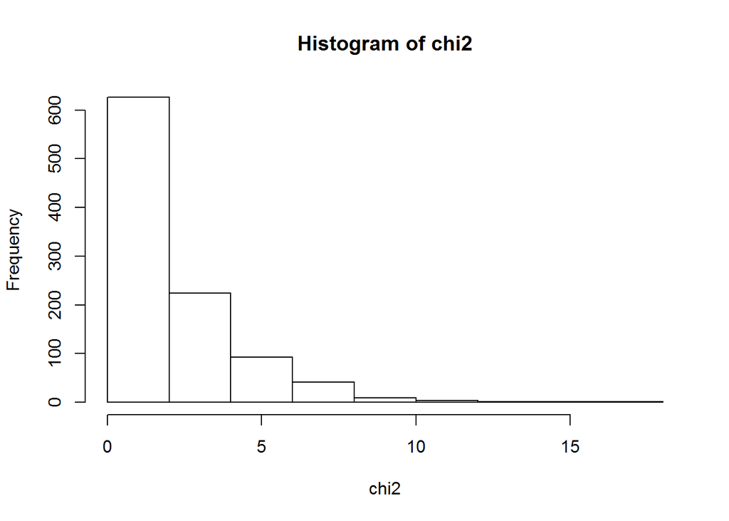

```r
hist(chi2)
```

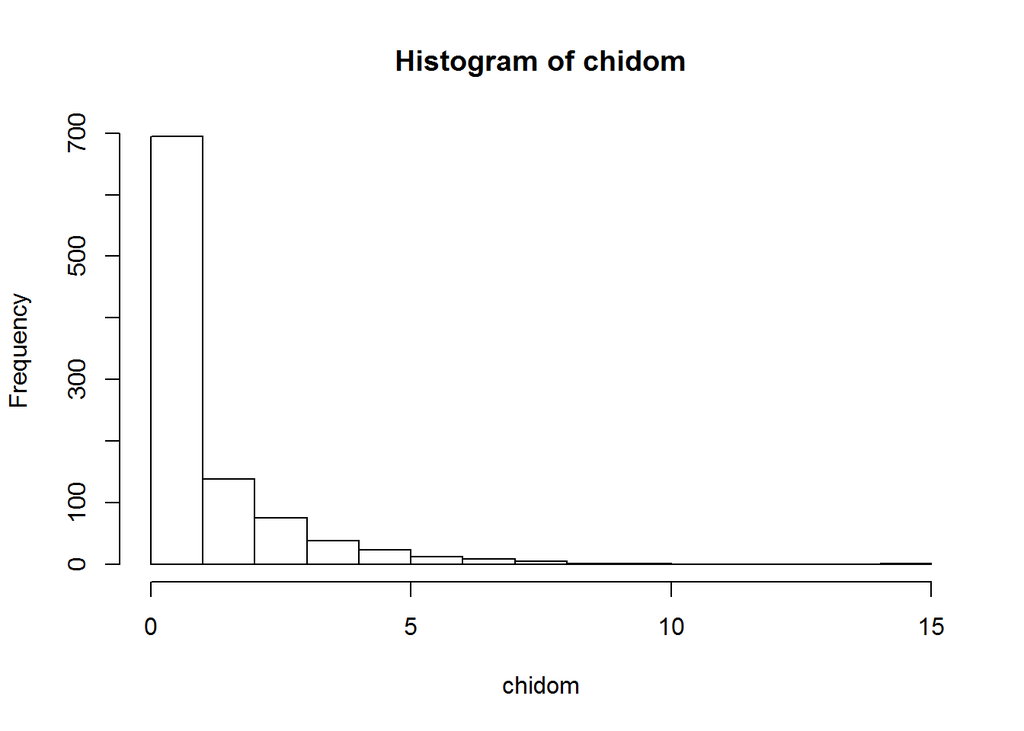

```r
hist(chidom)
```

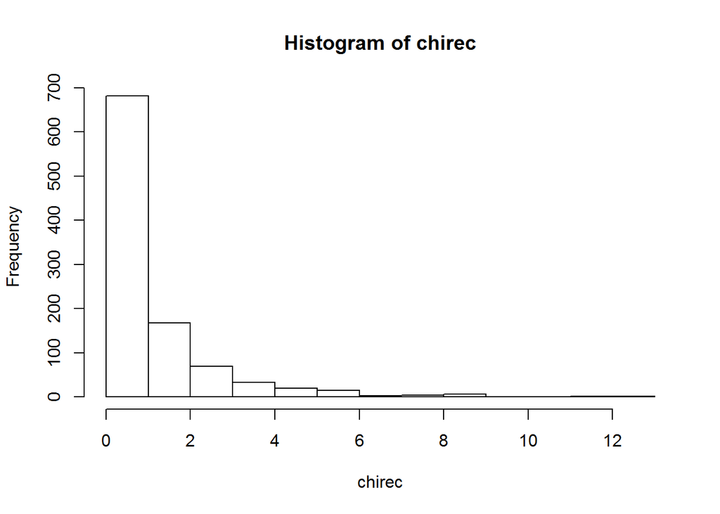

```r
hist(chirec)
```